# Problem Overview

The bank wants to improve its loan approval process by predicting customers likely to default on home equity loans. A machine learning model must be developed to automate this process, ensuring it is free from biases and interpretable enough for regulatory purposes.

**Project Objectives:**

- Build a classification model to predict loan defaults.
- Identify key factors influencing loan defaults.
- Ensure the model is interpretable for decision-making.
- Provide recommendations for improving the loan approval process.
- Ensure fairness and compliance with regulatory guidelines.

# Index

- Load Essential Libraries
- Load Dataset and Data Overview
- Exploratory Data Analytics
- Data Pre-processing
- Model Building Approach
- Model Building
- Model Comparison and Selection
- Insights and Recommendations

# Load Essential Libraries

```python
# Libraries for Data Manipulation and Numerical Operations
import numpy as np  # For numerical operations
import pandas as pd  # For data manipulation

# Set pandas display options for better readability of output
pd.set_option("display.max_columns", None)
pd.set_option("display.max_rows", 200)

# Libraries for Data Visualization
import matplotlib.pyplot as plt  # For plotting
import seaborn as sns  # For enhanced visualizations
from matplotlib.colors import LinearSegmentedColormap # For Custom Segmented Color Maps

# Set Seaborn aesthetic parameters
sns.set(
    context='notebook',
    style='darkgrid',
    font='sans-serif',
    font_scale=0.8,
    rc={'figure.figsize': (20, 14)}
)

# Libraries from Statsmodel
from statsmodels.stats.outliers_influence import variance_inflation_factor # For Multicollinearity Check

# Libraries for Sci-Kit Learn
from sklearn.impute import KNNImputer, SimpleImputer # For imputing missing values
from sklearn.model_selection import train_test_split, GridSearchCV # For spliting data in Train and Test set and performance tuning
from sklearn.preprocessing import StandardScaler, OneHotEncoder # For scalling the dataset and encoding categorical columns
from sklearn.linear_model import LogisticRegression
from sklearn.metrics import accuracy_score, precision_score, recall_score, f1_score, roc_auc_score, confusion_matrix
from sklearn.discriminant_analysis import LinearDiscriminantAnalysis
from sklearn.tree import DecisionTreeClassifier
from sklearn.ensemble import RandomForestClassifier, AdaBoostClassifier, GradientBoostingClassifier
from xgboost import XGBClassifier
from sklearn import metrics

# Library to resample data
from imblearn.over_sampling import SMOTE # for resampling data using Synthetic Minority Over-sampling Technique

# Libraries for Displaying Data in Notebooks
from IPython.display import display, HTML

# Ignore warnings to keep the output clean
import warnings
warnings.filterwarnings("ignore")
```

# Load Dataset and Data Overview

```python
# Load Dataset
path = '/content/drive/MyDrive/Colab Notebooks/06-Capstone/hmeq.csv'
df_hmeq = pd.read_csv(path)
```

```python
# Display the first few rows of the dataset
df_hmeq.head()
```

|  | BAD | LOAN | MORTDUE | VALUE | REASON | JOB | YOJ | DEROG | DELINQ | CLAGE | NINQ | CLNO | DEBTINC |
| --- | --- | --- | --- | --- | --- | --- | --- | --- | --- | --- | --- | --- | --- |
| 0 | 1 | 1100 | 25860.0 | 39025.0 | HomeImp | Other | 10.5 | 0.0 | 0.0 | 94.366667 | 1.0 | 9.0 | NaN |
| 1 | 1 | 1300 | 70053.0 | 68400.0 | HomeImp | Other | 7.0 | 0.0 | 2.0 | 121.833333 | 0.0 | 14.0 | NaN |
| 2 | 1 | 1500 | 13500.0 | 16700.0 | HomeImp | Other | 4.0 | 0.0 | 0.0 | 149.466667 | 1.0 | 10.0 | NaN |
| 3 | 1 | 1500 | NaN | NaN | NaN | NaN | NaN | NaN | NaN | NaN | NaN | NaN | NaN |
| 4 | 0 | 1700 | 97800.0 | 112000.0 | HomeImp | Office | 3.0 | 0.0 | 0.0 | 93.333333 | 0.0 | 14.0 | NaN |

```python
# Display the last few rows of the dataset
df_hmeq.tail()
```

|  | BAD | LOAN | MORTDUE | VALUE | REASON | JOB | YOJ | DEROG | DELINQ | CLAGE | NINQ | CLNO | DEBTINC |
| --- | --- | --- | --- | --- | --- | --- | --- | --- | --- | --- | --- | --- | --- |
| 5955 | 0 | 88900 | 57264.0 | 90185.0 | DebtCon | Other | 16.0 | 0.0 | 0.0 | 221.808718 | 0.0 | 16.0 | 36.112347 |
| 5956 | 0 | 89000 | 54576.0 | 92937.0 | DebtCon | Other | 16.0 | 0.0 | 0.0 | 208.692070 | 0.0 | 15.0 | 35.859971 |
| 5957 | 0 | 89200 | 54045.0 | 92924.0 | DebtCon | Other | 15.0 | 0.0 | 0.0 | 212.279697 | 0.0 | 15.0 | 35.556590 |
| 5958 | 0 | 89800 | 50370.0 | 91861.0 | DebtCon | Other | 14.0 | 0.0 | 0.0 | 213.892709 | 0.0 | 16.0 | 34.340882 |
| 5959 | 0 | 89900 | 48811.0 | 88934.0 | DebtCon | Other | 15.0 | 0.0 | 0.0 | 219.601002 | 0.0 | 16.0 | 34.571519 |

```python
# Check the Dataset Shape
print(f'The dataset has {df_hmeq.shape[0]} rows and {df_hmeq.shape[1]} columns.')
```

```
The dataset has 5960 rows and 13 columns.
```

```python
# Display Dataset Information
df_hmeq.info()
```

```
<class 'pandas.core.frame.DataFrame'>
RangeIndex: 5960 entries, 0 to 5959
Data columns (total 13 columns):
 #   Column   Non-Null Count  Dtype
---  ------   --------------  -----
 0   BAD      5960 non-null   int64
 1   LOAN     5960 non-null   int64
 2   MORTDUE  5442 non-null   float64
 3   VALUE    5848 non-null   float64
 4   REASON   5708 non-null   object
 5   JOB      5681 non-null   object
 6   YOJ      5445 non-null   float64
 7   DEROG    5252 non-null   float64
 8   DELINQ   5380 non-null   float64
 9   CLAGE    5652 non-null   float64
 10  NINQ     5450 non-null   float64
 11  CLNO     5738 non-null   float64
 12  DEBTINC  4693 non-null   float64
dtypes: float64(9), int64(2), object(2)
memory usage: 605.4+ KB
```

**Observations:**

- The dataset contains **5960 rows** and **13 columns**.
- The target variable (`BAD`) has no missing values (5960 non-null).
- **Missing values** are present in several columns, further checks are required
- **Numerical columns**: 9 columns of type `float64` and 2 columns of type `int64`.
- **Categorical columns**: 2 columns of type `object` (`REASON`, `JOB`).
- The dataset uses approximately **605.4 KB** of memory.

```python
# Data Statistics for Numerical Values
df_hmeq.describe(include='number').T
```

|  | count | mean | std | min | 25% | 50% | 75% | max |
| --- | --- | --- | --- | --- | --- | --- | --- | --- |
| BAD | 5960.0 | 0.199497 | 0.399656 | 0.000000 | 0.000000 | 0.000000 | 0.000000 | 1.000000 |
| LOAN | 5960.0 | 18607.969799 | 11207.480417 | 1100.000000 | 11100.000000 | 16300.000000 | 23300.000000 | 89900.000000 |
| MORTDUE | 5442.0 | 73760.817200 | 44457.609458 | 2063.000000 | 46276.000000 | 65019.000000 | 91488.000000 | 399550.000000 |
| VALUE | 5848.0 | 101776.048741 | 57385.775334 | 8000.000000 | 66075.500000 | 89235.500000 | 119824.250000 | 855909.000000 |
| YOJ | 5445.0 | 8.922268 | 7.573982 | 0.000000 | 3.000000 | 7.000000 | 13.000000 | 41.000000 |
| DEROG | 5252.0 | 0.254570 | 0.846047 | 0.000000 | 0.000000 | 0.000000 | 0.000000 | 10.000000 |
| DELINQ | 5380.0 | 0.449442 | 1.127266 | 0.000000 | 0.000000 | 0.000000 | 0.000000 | 15.000000 |
| CLAGE | 5652.0 | 179.766275 | 85.810092 | 0.000000 | 115.116702 | 173.466667 | 231.562278 | 1168.233561 |
| NINQ | 5450.0 | 1.186055 | 1.728675 | 0.000000 | 0.000000 | 1.000000 | 2.000000 | 17.000000 |
| CLNO | 5738.0 | 21.296096 | 10.138933 | 0.000000 | 15.000000 | 20.000000 | 26.000000 | 71.000000 |
| DEBTINC | 4693.0 | 33.779915 | 8.601746 | 0.524499 | 29.140031 | 34.818262 | 39.003141 | 203.312149 |

**Observations:**

- **BAD**: ~20% of the applicants defaulted (mean = 0.199), and it's a binary variable (0 or 1).
- **LOAN**: The average loan amount is \$18,607, with a large range (min = \$1,100, max = \$89,900).
- **MORTDUE**: Mortgage due varies widely (mean = \$73,760, max = \$399,550), indicating a diverse borrower pool.
- **VALUE**: Property values range significantly (mean = \$101,776, max = \$855,909), with 25th percentile at \$66,075 and 75th at \$119,824.
- **YOJ (Years on Job)**: Median is 7 years, suggesting stability; however, some applicants have very low job tenure (min = 0).
- **DEROG and DELINQ**: Most applicants have no derogatory reports or delinquencies (75th percentile = 0).
- **CLAGE**: Credit age is quite high on average (mean = ~179 months), indicating experienced credit users.
- **NINQ (Credit Inquiries)**: Most applicants have fewer recent credit inquiries (median = 1, max = 17).
- **CLNO (Credit Lines)**: The average number of credit lines is 21, with a wide spread (min = 0, max = 71).
- **DEBTINC**: The debt-to-income ratio has a mean of 33.78%, but some applicants have extremely high ratios (max = 203.31%), which could indicate financial stress.

```python
# Statistics for Categorical Values
df_hmeq.describe(include='object').T
```

|  | count | unique | top | freq |
| --- | --- | --- | --- | --- |
| REASON | 5708 | 2 | DebtCon | 3928 |
| JOB | 5681 | 6 | Other | 2388 |

**Observations:**

- **REASON**: The majority of applicants (3928 out of 5708) applied for loans due to **Debt Consolidation**, with **2 unique categories**.
- **JOB**: The most common job category is **Other** (2388 out of 5681), with **6 unique job categories** in total.

```python
# Check for Duplicates
df_hmeq.duplicated().sum()
```

```
0
```

**Observations:**

- There are no duplicate records.

```python
# Check for Missing Values
df_hmeq_missing = df_hmeq.isna().sum()[df_hmeq.isnull().sum() > 0]  # Get count of missing values
df_hmeq_missing = df_hmeq_missing.to_frame(name='missing_count').rename_axis('Column_name')  # Convert series to DataFrame
df_hmeq_missing['percentage'] = round(df_hmeq_missing['missing_count'] / len(df_hmeq) * 100, 2)  # Calculate percentage
df_hmeq_missing.sort_values(by=df_hmeq_missing.columns[1], ascending=False, inplace=True)  # Sort by percentage, highest first
df_hmeq_missing
```

| Column_name | missing_count | percentage |
| --- | --- | --- |
| DEBTINC | 1267 | 21.26 |
| DEROG | 708 | 11.88 |
| DELINQ | 580 | 9.73 |
| MORTDUE | 518 | 8.69 |
| YOJ | 515 | 8.64 |
| NINQ | 510 | 8.56 |
| CLAGE | 308 | 5.17 |
| JOB | 279 | 4.68 |
| REASON | 252 | 4.23 |
| CLNO | 222 | 3.72 |
| VALUE | 112 | 1.88 |

**Observations on Missing Data:**

- Several features contain missing values, with **DEBTINC** having the highest proportion at **21.26%**, followed by **DEROG** and **DELINQ** with **11.88%** and **9.73%**, respectively.
- Features like **MORTDUE**, **YOJ**, and **NINQ** also have moderate levels of missing data, ranging from **8.69%** to **8.56%**.
- Missing data could impact the model’s predictive power if not handled properly, especially in features crucial for loan default prediction.
- We will explore options to appropriately impute both numerical and categorical missing values during Data Pre-Processing stage.

# Exploratory Data Analysis (EDA)

- Univariate Analysis - Numerical Features
- Univariate Analysis - Categorical Features
- Bivariate Analysis - Numerical Features vs Target Variable (BAD)
- Bivariate Analysis - Categorical Features vs Target Variable (BAD)
- Multivariate Analysis - Correlation Heatmap (Numerical Features)
- EDA Summary and Key Insights

## Functions to aide EDA

```python
import math

# Plots boxplots and histograms for numerical features of a DataFrame.
def plot_numerical(dataframe, target_variable=None):

    # Extract numerical variables
    if target_variable:
        numeric_columns = dataframe.select_dtypes(include=['float64', 'int64']).drop(target_variable, axis=1).columns
    else:
        numeric_columns = dataframe.select_dtypes(include=['float64', 'int64']).columns
    num_vars = len(numeric_columns)

    # Calculate the number of rows for the subplot
    num_rows = (num_vars // 4) + (1 if num_vars % 4 != 0 else 0)

    # Set up the matplotlib figure
    fig, axes = plt.subplots(2 * num_rows, 4, figsize=(20, 4 * num_rows * 1.25), constrained_layout=True, gridspec_kw={'height_ratios': [1, 4] * num_rows})

    # Loop through the numerical variables to create boxplots and histograms
    for i, column in enumerate(numeric_columns):
        # Define the row and column index in the subplot grid
        row = (i // 4) * 2
        col = i % 4

        # Create a boxplot for the variable
        sns.boxplot(data=dataframe, x=column, ax=axes[row, col])
        axes[row, col].set_title(f'Box Plot and Histogram for {column}', fontsize=12)
        axes[row, col].tick_params(labelbottom=False)  # Remove x-ticks for the boxplot
        axes[row, col].set_xlabel('')  # Remove x-axis label for the boxplot

        # Create a histogram for the variable
        sns.histplot(data=dataframe, x=column, kde=True, ax=axes[row + 1, col], binwidth=None)
        axes[row + 1, col].set_title('')  # Remove title for the histogram
        axes[row + 1, col].set_xlabel(f'{column}\n\n')  # Set x-axis label for the histogram

    # Remove the excess axes
    i += 1
    delrow =  (i // 4) * 2
    delcol = i % 4
    fig.delaxes(axes[delrow, delcol])
    fig.delaxes(axes[delrow, delcol + 1])
    fig.delaxes(axes[delrow + 1, delcol])
    fig.delaxes(axes[delrow + 1, delcol + 1])

    plt.show()

# Display bar plots for categorical features
def plot_categorical_bars(data):
    """
    Plots bar plots for all categorical columns in the DataFrame.

    Parameters:
        data (DataFrame): The pandas DataFrame containing the data.
    """
    # Identify categorical columns: Either by dtype 'object' or by checking the number of unique values
    categorical_columns = [col for col in data.columns if data[col].dtype == 'object']

    # Set the number of columns for subplot grid
    ncols = 2 if len(categorical_columns) > 2 else len(categorical_columns)
    nrows = (len(categorical_columns) + ncols - 1) // ncols  # Calculate the number of rows needed

    # Set dynamic width of the figure based on the number of columns
    fig_width = 20  # Each subplot approx 5 inches wide
    fig_height = 8 * nrows  # Each subplot approx 5 inches tall

    fig, axes = plt.subplots(nrows=nrows, ncols=ncols, figsize=(fig_width, fig_height))
    axes = axes.flatten() if nrows > 1 or ncols > 1 else [axes]  # Handle the case of a single subplot

    # Loop over the categorical columns and create a bar plot for each
    for i, col in enumerate(categorical_columns):
        sns.countplot(x=col, data=data, ax=axes[i])
        axes[i].set_title(f'Bar Plot of {col}', fontsize=12)
        axes[i].set_xlabel('')
        axes[i].set_ylabel('Count')
        axes[i].tick_params(axis='x', rotation=45)  # Rotate x-axis labels

    # Hide unused subplots if any
    for j in range(i + 1, len(axes)):
        axes[j].set_visible(False)

    plt.tight_layout()
    plt.show()

# Use Top 10 correlated features to target column (Default), evaluate each with the target column
def plot_boxplots(features_df, target_series):
    """
    Parameters:
    - features_df: pandas DataFrame containing the numerical features
    - target_series: pandas Series containing the target variable
    """
    # Get column names of the features
    numeric_cols = features_df.columns

    # Number of numerical features
    num_features = len(numeric_cols)
    num_rows = (num_features + 3) // 3  # Calculate the number of rows needed for subplots

    # Set the figure size based on the number of rows
    plt.figure(figsize=(20, 5 * num_rows))

    # Loop through each numerical column and create a boxplot against the target variable
    for i, col in enumerate(numeric_cols, 1):
        plt.subplot(num_rows, 3, i)
        sns.boxplot(x=target_series, y=features_df[col])
        plt.title(f'{col} vs Default (Target)', fontsize=12)

    plt.tight_layout()
    plt.show()

# Use Top 10 categorical features to evaluate each with the target column (Default)
def plot_stacked_barcharts(features_df, target_series):
    """
    Parameters:
    - features_df: pandas DataFrame containing the categorical features
    - target_series: pandas Series containing the target variable
    """
    # Get column names of the categorical features
    categorical_cols = features_df.columns

    # Create a gradient colormap from white to steelblue
    steelblue_gradient = LinearSegmentedColormap.from_list("steelblue_gradient", ['lightsteelblue', 'steelblue'])

    # Number of categorical features
    num_features = len(categorical_cols)
    num_rows = (num_features + 2) // 3  # Calculate the number of rows needed for subplots (3 per row)

    # Set the figure size based on the number of rows
    plt.figure(figsize=(20, 5 * num_rows))

    # Loop through each categorical column and create a stacked bar chart against the target variable
    for i, col in enumerate(categorical_cols, 1):
        plt.subplot(num_rows, 3, i)

        # Create a crosstab for the relationship between the categorical feature and the target
        crosstab = pd.crosstab(features_df[col], target_series)

        # Plot the stacked bar chart
        crosstab.plot(kind='bar', stacked=True, ax=plt.gca(), colormap=steelblue_gradient)

        # Set title and labels
        plt.title(f'{col} vs Default (Target)', fontsize=12)
        plt.ylabel('Proportion')
        plt.xlabel(col)

    plt.tight_layout()
    plt.show()

# Generate a correlation matrix for numerical features
def plot_correlation_heatmap(data):
    # Filter out only numerical columns
    numeric_data = data.select_dtypes(include=['float64', 'int64'])

    # Calculate the correlation matrix
    corr_matrix = numeric_data.corr()

    # Create the heatmap
    plt.figure(figsize=(12, 8))
    sns.heatmap(corr_matrix, annot=True, cmap='coolwarm', fmt='.2f', linewidths=0.5)

    # Add a title
    plt.title('Correlation Heatmap', fontsize=16)

    # Display the plot
    plt.show()

# Function to calculate VIF for numerical features
def calculate_vif(data):
    # Filter out only numerical columns
    numeric_data = data.select_dtypes(include=['float64', 'int64']).dropna()

    # Add a constant for the regression model
    X = numeric_data.assign(const=1)

    # Create an empty DataFrame to store VIF values
    vif_data = pd.DataFrame()
    vif_data['Feature'] = X.columns

    # Calculate VIF for each feature
    vif_data['VIF'] = [variance_inflation_factor(X.values, i) for i in range(X.shape[1])]

    # Return VIF excluding the constant term
    return vif_data[vif_data['Feature'] != 'const']
```

## Univariate Analysis - Numerical Values

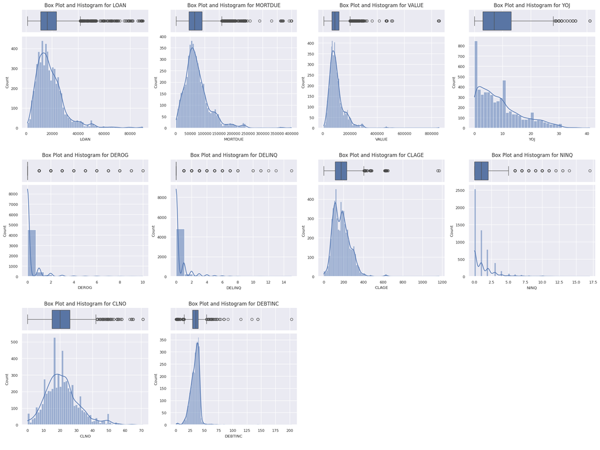

```python
# Boxplots and Histogram to under Numerical Features' Distribution
plot_numerical(df_hmeq,['BAD'])
```

**Observations:**

- **Distribution**:
  - **LOAN, MORTDUE, and VALUE**: These features might display **right-skewed distributions**, indicating a higher concentration of smaller values with a few large outliers.
  - **DEBTINC**: The distribution could also be skewed, with most applicants having a moderate debt-to-income ratio but a few with exceptionally high values.
- **Skewness**:
  - **LOAN**: If the histogram shows a long tail towards higher values, it suggests the feature is **positively skewed** (right-skewed), which could affect model assumptions, especially for linear models.
  - **DELINQ and DEROG**: These features may show **positive skewness**, as most applicants are likely to have few or no delinquencies or derogatory reports, with a few having high counts.
- **Outliers**:
  - **DEBTINC and LOAN**: Boxplots for these features are likely to show **outliers** with extreme values, especially for larger loans and high debt-to-income ratios. These outliers may need to be addressed through capping or transformation.
  - **DEROG, DELINQ, and NINQ**: A small number of applicants may have disproportionately high derogatory reports or credit inquiries, appearing as **outliers** on the boxplots.
  - **CLAGE**: While this may show a fairly normal distribution, there could still be **outliers** with very high credit ages, reflecting long-term credit users.

## Univariate Analysis - Categorical Values

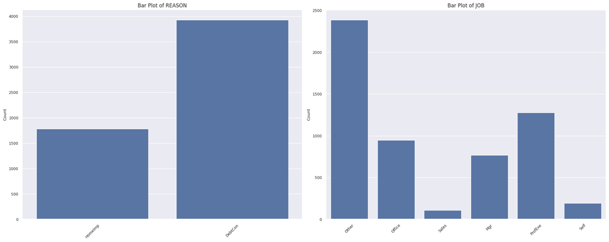

```python
# Display barplot for categorical values
plot_categorical_bars(df_hmeq)
```

**Observations:**

- **REASON**: The majority of applicants fall under the **DebtCon (Debt Consolidation)** category, with fewer applicants in the **HomeImp (Home Improvement)** category. This indicates that consolidating debt is a more common reason for applying for loans.
- **JOB**: The **Other** job category has the highest frequency, suggesting a diverse range of applicants whose occupations do not fit standard categories like **Manager** or **Office**. The distribution is skewed towards the **Other** category, with fewer applicants in more specific job types.
- **Skewness in Distribution**: Both **REASON** and **JOB** show an uneven distribution, with the top categories dominating. This might reflect biases in the dataset or the types of customers the bank tends to attract.

## Bivariate Analysis - Numerical Features vs Target Variable (BAD)

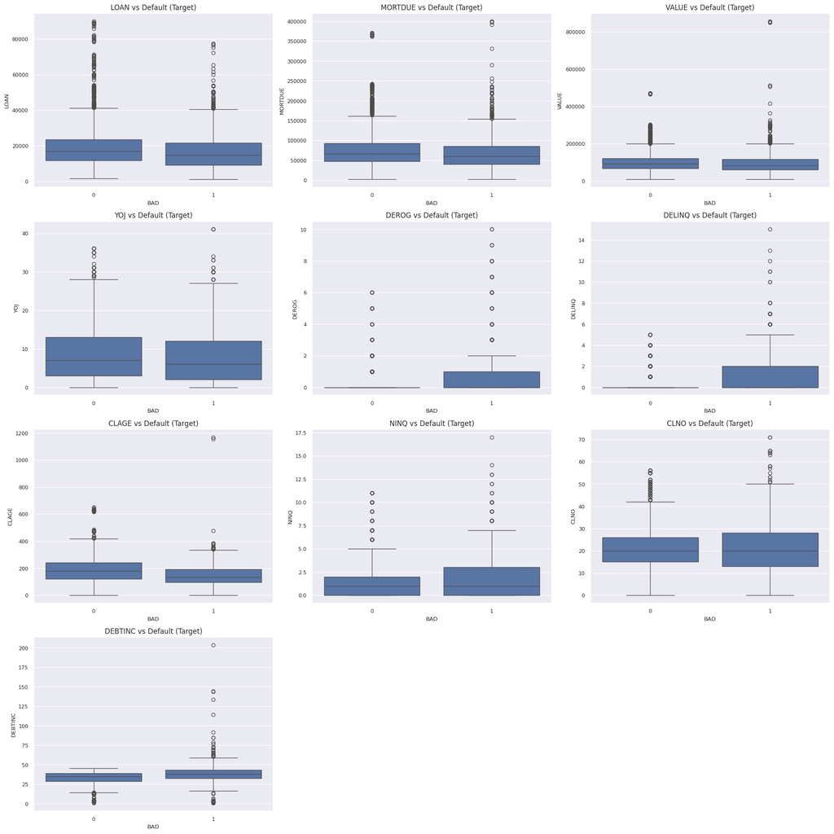

```python
# Draw Boxplots showing Predictor's relation with Target Variable (BAD)
plot_boxplots(df_hmeq.select_dtypes(include=['int64','float64']).drop('BAD', axis=1), df_hmeq['BAD'])
```

**Observations:**

## Bivariate Analysis - Categorical Features vs Target Variable (BAD)

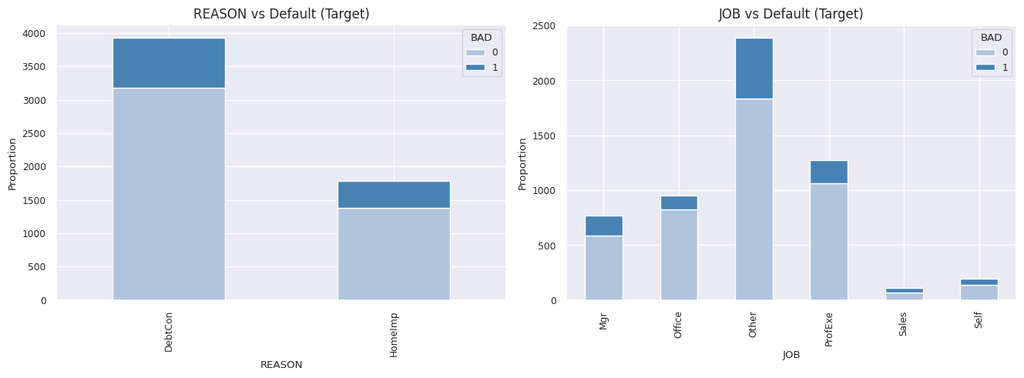

```python
# Display Stacked Barchart to show relation of Categorical Variables to Target Variable
plot_stacked_barcharts(df_hmeq.select_dtypes(include=['object']), df_hmeq['BAD'])
```

**Observations:**

## Multivariate Analysis - Correlation Heatmap

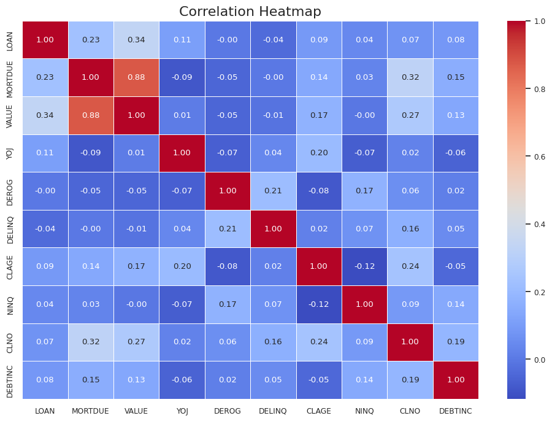

```python
# Identify correlation between numeric features using Correlation Heatmap
plot_correlation_heatmap(df_hmeq.drop(columns=['BAD']))
```

**Observations:**

## EDA Summary and Key Insights

The analysis highlighted significant patterns in both numerical and categorical features, offering a clearer understanding of loan default risk.

# Data Pre-Processing

- Missing Values Imputation
- Outlier Treatment
- Encode Categorical Columns
- Train-Validation-Test Split
- Multicollinearity Check (Linear models only)
- Scaling Dataset (Linear Models only)
- Data Pre-process Summary

## Functions to assist in Data Pre-processing

```python
# Imputes missing values for both training and testing datasets using KNN for numerical features and SimpleImputer (most frequent) for categorical features.
def impute_missing_values_knn(dataframe):
    """
    Parameters:
    - dataframe: DataFrame.

    Returns:
    - dataframe_imputed: Imputed data set (pandas DataFrame).
    """

    # Separate numerical and categorical columns in the training data
    numerical_cols = dataframe.select_dtypes(include=['float64', 'int64']).columns
    categorical_cols = dataframe.select_dtypes(include=['object']).columns

    # Imputation for numerical columns using KNN (fit on X_train, transform on both)
    knn_imputer = KNNImputer(n_neighbors=5)
    dataframe[numerical_cols] = knn_imputer.fit_transform(dataframe[numerical_cols])

    # Imputation for categorical columns using most frequent (fit on X_train, transform on both)
    cat_imputer = SimpleImputer(strategy='most_frequent')
    dataframe[categorical_cols] = cat_imputer.fit_transform(dataframe[categorical_cols])

    return dataframe

# Function to treat outliers for each column with outliers, excluding target column
def treat_outliers(df, exclude_columns):
    """
    Parameters:
    - df: pandas DataFrame
    - exclude_columns: list of columns to exclude from the outlier treatment.

    Returns:
    - DataFrame with outliers treated for the specified numerical columns.
    """
    # Exclude specified columns from outlier treatment
    numeric_cols = df.select_dtypes(include=['number']).columns.difference(exclude_columns)

    for column in numeric_cols:
        Q1 = df[column].quantile(0.25)
        Q3 = df[column].quantile(0.75)
        IQR = Q3 - Q1

        # Define the lower and upper bounds for outliers
        lower_bound = Q1 - 1.5 * IQR
        upper_bound = Q3 + 1.5 * IQR

        # Replace lower outliers with the lower bound and upper outliers with the upper bound
        df[column] = df[column].apply(lambda x: lower_bound if x < lower_bound else (upper_bound if x > upper_bound else x))

    return df

# Encodes categorical features in the DataFrame using one-hot encoding.
def encode_categorical(df):
    """
    Parameters:
    - df: DataFrame containing the features.

    Returns:
    - DataFrame with categorical features one-hot encoded.
    """
    # Select categorical columns
    categorical_cols = df.select_dtypes(include=['object']).columns

    # Apply one-hot encoding
    df_encoded = pd.get_dummies(df, columns=categorical_cols, drop_first=True)

    # Convert only boolean columns to integers (1/0)
    for col in df_encoded.columns:
        if df_encoded[col].dtype == 'bool':
            df_encoded[col] = df_encoded[col].astype(int)

    return df_encoded
```

## Missing Value Imputation

During the data overview we identified that some columns have missing values, but the percentage is low, so we will impute them before building models. We'll use **KNN imputation** for numerical columns and **SimpleImputer** with the most frequent value for categorical columns.

**Reasons for Choosing Imputation Methods**:

- **KNN Imputation (Numerical Data)**: Accounts for relationships between variables like loan amounts and debt-to-income ratios, leveraging patterns in similar rows.
- **Most Frequent Value (Categorical Data)**: Replaces missing values with the most common category, which is reasonable for features like **REASON** and **JOB**.

```python
# Calling function to impute missing values
df_hmeq_imputed = impute_missing_values_knn(df_hmeq)

# Check for missing values
print('Check Missing values dataset:\n')
display(df_hmeq_imputed.isna().sum())
```

```
Check Missing values dataset:
```

|  | 0 |
| --- | --- |
| BAD | 0 |
| LOAN | 0 |
| MORTDUE | 0 |
| VALUE | 0 |
| REASON | 0 |
| JOB | 0 |
| YOJ | 0 |
| DEROG | 0 |
| DELINQ | 0 |
| CLAGE | 0 |
| NINQ | 0 |
| CLNO | 0 |
| DEBTINC | 0 |

**dtype:** int64

**Conclusion:**

- Missing values have been corrected and now we will proceed to treat the outliers.

## Outlier Treatment

Outlier treatment is essential to prevent extreme values from distorting model performance, especially in financial data. The following code uses **IQR-based outlier treatment** to cap outliers within acceptable limits.

- No Outlier Treatment for **DEROG**, **DELINQ**, and **NINQ** due to their discrete nature.
- **Identifying Outliers**: The interquartile range (IQR) method calculates the range between the 25th and 75th percentiles, defining outliers as values outside this range.
- **Setting Bounds**: The lower and upper bounds are set at 1.5 times the IQR below Q1 and above Q3, respectively.
- **Capping Values**: Outliers below the lower bound are replaced by the lower bound, and those above the upper bound are capped at the upper limit.
- **Excluding Target Variable**: The target variable is excluded from outlier treatment to avoid impacting the response variable.

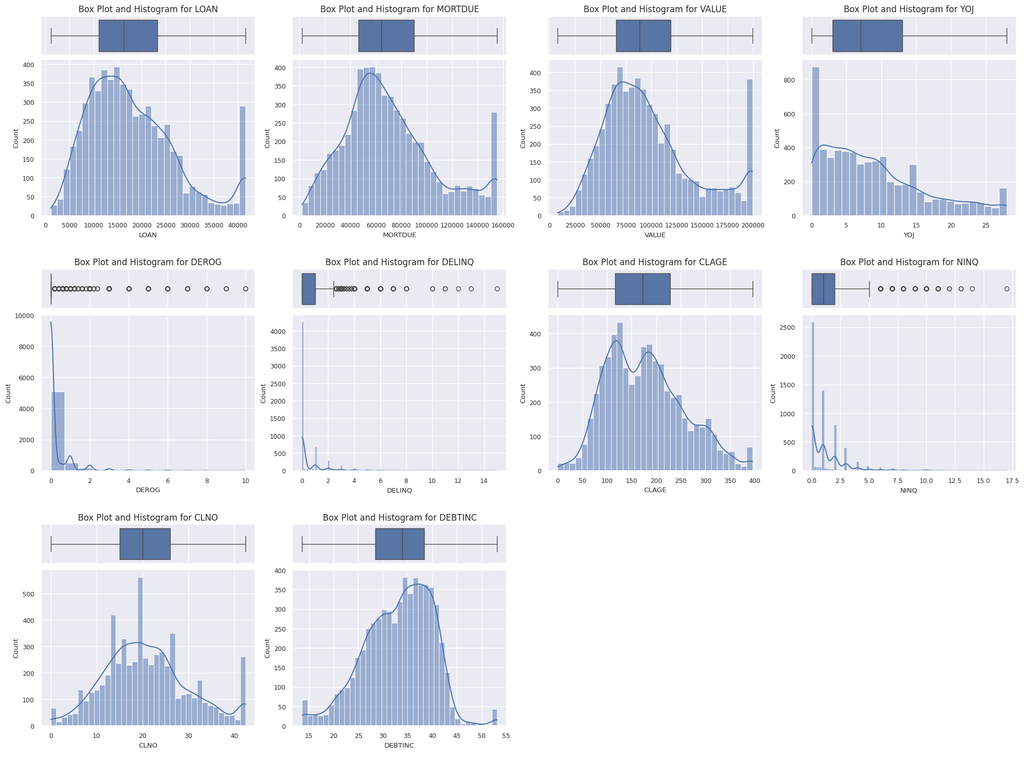

```python
# Treat outliers in Train Set
df_hmeq_imputed_ot = treat_outliers(df_hmeq_imputed, ['BAD','DEROG','DELINQ','NINQ'])

# Verify that Outliers are treated
plot_numerical(df_hmeq_imputed_ot,['BAD'])
```

**Observations:**

- Outliers for selected columns have been treated.

## Encoding Categorical Columns

We will encode the categorical columns and replace the output with 0s and 1s in preparation for model building.

- **One-hot Encoding:** One-Hot encoding will help us convert categorical values into binary representations.
- **No Clear Ordinal Values:** We chose to use One-Hot encoding for all categorical features as they do not demonstrate clear ordinal values, particularly in the JOB column, where no distinct hierarchy exists across roles.

```python
# Encode categorical columns using one-hot encoding
df_hmeq_final = encode_categorical(df_hmeq_imputed_ot)
display(df_hmeq_final.head())
```

|  | BAD | LOAN | MORTDUE | VALUE | YOJ | DEROG | DELINQ | CLAGE | NINQ | CLNO | DEBTINC | REASON_HomeImp | JOB_Office | JOB_Other | JOB_ProfExe | JOB_Sales | JOB_Self |
| --- | --- | --- | --- | --- | --- | --- | --- | --- | --- | --- | --- | --- | --- | --- | --- | --- | --- |
| 0 | 1.0 | 1100.0 | 25860.0 | 39025.0 | 10.5 | 0.0 | 0.0 | 94.366667 | 1.0 | 9.0 | 23.314070 | 1 | 0 | 1 | 0 | 0 | 0 |
| 1 | 1.0 | 1300.0 | 70053.0 | 68400.0 | 7.0 | 0.0 | 2.0 | 121.833333 | 0.0 | 14.0 | 40.532794 | 1 | 0 | 1 | 0 | 0 | 0 |
| 2 | 1.0 | 1500.0 | 13500.0 | 16700.0 | 4.0 | 0.0 | 0.0 | 149.466667 | 1.0 | 10.0 | 36.196050 | 1 | 0 | 1 | 0 | 0 | 0 |
| 3 | 1.0 | 1500.0 | 48080.6 | 56090.8 | 6.8 | 0.0 | 0.4 | 110.973073 | 0.4 | 10.8 | 29.512385 | 0 | 0 | 1 | 0 | 0 | 0 |
| 4 | 0.0 | 1700.0 | 97800.0 | 112000.0 | 3.0 | 0.0 | 0.0 | 93.333333 | 0.0 | 14.0 | 34.370509 | 1 | 1 | 0 | 0 | 0 | 0 |

## Train-Validation-Test Split

In this step, we split the dataset into training, validation, and testing sets to evaluate model performance more effectively.

- **Feature/Target Separation**: We segregated predictors (features) and the target variable to ensure the model is trained on relevant data.
- **Train/Validation/Test Split**: The dataset was split into training, validation, and test sets. The validation set helps us fine-tune models, while the test set evaluates performance on unseen data for accurate assessment.

This ensures the model is tested after proper tuning for better generalization.

```python
# Separate predictors and target variabl
X = df_hmeq_final.drop(columns=['BAD'])
y = df_hmeq_final['BAD']

print('Top 5 rows with predictors:\n')
display(X.head())
print('\nTop 5 rows with target variable:\n')
display(y.head())
```

```
Top 5 rows with predictors:
```

|  | LOAN | MORTDUE | VALUE | YOJ | DEROG | DELINQ | CLAGE | NINQ | CLNO | DEBTINC | REASON_HomeImp | JOB_Office | JOB_Other | JOB_ProfExe | JOB_Sales | JOB_Self |
| --- | --- | --- | --- | --- | --- | --- | --- | --- | --- | --- | --- | --- | --- | --- | --- | --- |
| 0 | 1100.0 | 25860.0 | 39025.0 | 10.5 | 0.0 | 0.0 | 94.366667 | 1.0 | 9.0 | 23.314070 | 1 | 0 | 1 | 0 | 0 | 0 |
| 1 | 1300.0 | 70053.0 | 68400.0 | 7.0 | 0.0 | 2.0 | 121.833333 | 0.0 | 14.0 | 40.532794 | 1 | 0 | 1 | 0 | 0 | 0 |
| 2 | 1500.0 | 13500.0 | 16700.0 | 4.0 | 0.0 | 0.0 | 149.466667 | 1.0 | 10.0 | 36.196050 | 1 | 0 | 1 | 0 | 0 | 0 |
| 3 | 1500.0 | 48080.6 | 56090.8 | 6.8 | 0.0 | 0.4 | 110.973073 | 0.4 | 10.8 | 29.512385 | 0 | 0 | 1 | 0 | 0 | 0 |
| 4 | 1700.0 | 97800.0 | 112000.0 | 3.0 | 0.0 | 0.0 | 93.333333 | 0.0 | 14.0 | 34.370509 | 1 | 1 | 0 | 0 | 0 | 0 |

```
Top 5 rows with target variable:
```

|  | BAD |
| --- | --- |
| 0 | 1.0 |
| 1 | 1.0 |
| 2 | 1.0 |
| 3 | 1.0 |
| 4 | 0.0 |

**dtype:** float64

```python
# Split full dataset into train and test sets
X_train_full, X_test, y_train_full, y_test = train_test_split(X, y, test_size=0.2, random_state=42, stratify=y)

print('Full Train and Test Sets:\n')
print(f'X_train_full shape: {X_train_full.shape}')
print(f'X_test shape: {X_test.shape}')
print(f'y_train_full shape: {y_train_full.shape}')
print(f'y_test shape: {y_test.shape}')

# Further split training set into train and validation sets
X_train, X_val, y_train, y_val = train_test_split(X_train_full, y_train_full, test_size=0.2, random_state=42, stratify=y_train_full)

print('\nTrain and Validation Sets:\n')
print(f'X_train shape: {X_train.shape}')
print(f'X_val shape: {X_val.shape}')
print(f'y_train shape: {y_train.shape}')
print(f'y_val shape: {y_val.shape}')
```

```
Full Train and Test Sets:

X_train_full shape: (4768, 16)
X_test shape: (1192, 16)
y_train_full shape: (4768,)
y_test shape: (1192,)

Train and Validation Sets:

X_train shape: (3814, 16)
X_val shape: (954, 16)
y_train shape: (3814,)
y_val shape: (954,)
```

## Multicollinearity Check (Linear models only)

We will be using linear models like **Logistic Regression** and **Linear Discriminant Analysis**, it is crucial to check for multicollinearity among the features and address it if necessary.

```python
vif_result = calculate_vif(X_train)
display(vif_result.sort_values(by='VIF', ascending=False))
```

|  | Feature | VIF |
| --- | --- | --- |
| 2 | VALUE | 3.469266 |
| 1 | MORTDUE | 3.203948 |
| 12 | JOB_Other | 2.622552 |
| 13 | JOB_ProfExe | 2.219166 |
| 11 | JOB_Office | 1.916907 |
| 8 | CLNO | 1.302018 |
| 15 | JOB_Self | 1.270643 |
| 0 | LOAN | 1.256190 |
| 6 | CLAGE | 1.158137 |
| 14 | JOB_Sales | 1.152413 |
| 10 | REASON_HomeImp | 1.114662 |
| 9 | DEBTINC | 1.112177 |
| 4 | DEROG | 1.098687 |
| 5 | DELINQ | 1.092507 |
| 3 | YOJ | 1.086987 |
| 7 | NINQ | 1.083350 |

**Observations:**

- **No Immediate Concern:** While VALUE and MORTDUE have relatively higher VIF values, they are still below the common threshold of 5, meaning they do not present a severe multicollinearity problem.

## Dataset Scaling using StandardScaler (Linear models only)

Scaling is essential for models that are sensitive to the magnitude of features, such as **Logistic Regression** and **Linear Discriminant Analysis**. These models can be influenced by features with larger values, leading to biased model performance.

```python
# Scale the predictor variables
scaler = StandardScaler()
X_train_scaled = X_train.copy()
X_val_scaled = X_val.copy()
X_test_scaled = X_test.copy()

# Fit the scaler on X_train and transform X_train
X_train_scaled[X_train_scaled.columns] = scaler.fit_transform(X_train[X_train_scaled.columns])

# Apply the same scaler to X_test and X_val datasets
X_test_scaled[X_test_scaled.columns] = scaler.transform(X_test[X_test_scaled.columns])
X_val_scaled[X_val_scaled.columns] = scaler.transform(X_val[X_val_scaled.columns])

print('Scaled Training Dataset:')
display(X_train_scaled.head())
print('\nScaled Validation Dataset:')
display(X_val_scaled.head())
print('\nScaled Test Dataset:')
display(X_test_scaled.head())
```

```
Scaled Training Dataset:
```

|  | LOAN | MORTDUE | VALUE | YOJ | DEROG | DELINQ | CLAGE | NINQ | CLNO | DEBTINC | REASON_HomeImp | JOB_Office | JOB_Other | JOB_ProfExe | JOB_Sales | JOB_Self |
| --- | --- | --- | --- | --- | --- | --- | --- | --- | --- | --- | --- | --- | --- | --- | --- | --- |
| 2219 | -0.451656 | 0.109675 | -0.113334 | -0.262479 | -0.344 | 2.149522 | 0.044098 | -0.701124 | 1.286339 | 0.895970 | -0.651304 | -0.424782 | 1.087162 | -0.520897 | -0.140663 | -0.176322 |
| 2715 | -0.266884 | -1.043493 | -0.626532 | -0.262479 | -0.344 | -0.460507 | 0.997462 | -0.097547 | -0.534220 | -1.435184 | -0.651304 | -0.424782 | -0.919826 | 1.919767 | -0.140663 | -0.176322 |
| 5213 | 1.124338 | 1.088158 | 2.301961 | 1.926992 | -0.344 | -0.460507 | 0.026690 | -0.701124 | -0.320037 | -1.383765 | -0.651304 | -0.424782 | 1.087162 | -0.520897 | -0.140663 | -0.176322 |
| 2189 | -0.462525 | -0.151388 | -0.293733 | 0.695414 | -0.344 | -0.460507 | -0.795508 | -0.701124 | 0.322514 | 0.542311 | -0.651304 | 2.354150 | -0.919826 | -0.520897 | -0.140663 | -0.176322 |
| 1951 | -0.549476 | -0.109665 | -0.113424 | 2.474360 | -0.344 | -0.460507 | -0.103279 | -0.097547 | -0.748404 | 1.182170 | 1.535381 | 2.354150 | -0.919826 | -0.520897 | -0.140663 | -0.176322 |

```
Scaled Validation Dataset:
```

|  | LOAN | MORTDUE | VALUE | YOJ | DEROG | DELINQ | CLAGE | NINQ | CLNO | DEBTINC | REASON_HomeImp | JOB_Office | JOB_Other | JOB_ProfExe | JOB_Sales | JOB_Self |
| --- | --- | --- | --- | --- | --- | --- | --- | --- | --- | --- | --- | --- | --- | --- | --- | --- |
| 2277 | -0.429918 | 2.378587 | 1.833635 | -0.262479 | 0.402028 | 0.409502 | 0.186317 | 1.713183 | 0.536697 | 1.174072 | -0.651304 | -0.424782 | -0.919826 | 1.919767 | -0.140663 | -0.176322 |
| 4696 | 0.754795 | 1.085365 | 0.967168 | 0.284888 | 2.142760 | -0.460507 | 0.075776 | 2.316759 | -0.320037 | 1.090548 | -0.651304 | -0.424782 | -0.919826 | -0.520897 | -0.140663 | -0.176322 |
| 5830 | 2.580775 | -0.657679 | 0.108434 | 0.011205 | -0.344000 | -0.460507 | 0.424952 | 1.109606 | 1.500523 | 0.809520 | 1.535381 | -0.424782 | -0.919826 | -0.520897 | -0.140663 | 5.671439 |
| 5917 | 2.580775 | -0.161889 | 1.034485 | 0.011205 | -0.344000 | -0.460507 | -0.812552 | -0.701124 | -1.069679 | 0.976144 | 1.535381 | 2.354150 | -0.919826 | -0.520897 | -0.140663 | -0.176322 |
| 3960 | 0.309169 | -0.011445 | 0.074437 | -0.809847 | -0.344000 | -0.460507 | 0.456668 | -0.097547 | -0.855496 | -0.038787 | 1.535381 | -0.424782 | 1.087162 | -0.520897 | -0.140663 | -0.176322 |

```
Scaled Test Dataset:
```

|  | LOAN | MORTDUE | VALUE | YOJ | DEROG | DELINQ | CLAGE | NINQ | CLNO | DEBTINC | REASON_HomeImp | JOB_Office | JOB_Other | JOB_ProfExe | JOB_Sales | JOB_Self |
| --- | --- | --- | --- | --- | --- | --- | --- | --- | --- | --- | --- | --- | --- | --- | --- | --- |
| 4798 | 0.787402 | -0.807257 | -0.588342 | 1.379624 | -0.344 | -0.460507 | 0.073691 | -0.097547 | 0.108330 | 0.077116 | -0.651304 | 2.354150 | -0.919826 | -0.520897 | -0.140663 | -0.176322 |
| 3716 | 0.189611 | -1.031512 | -0.803256 | 0.695414 | -0.344 | -0.460507 | -0.742711 | -0.097547 | -0.427129 | 0.678666 | -0.651304 | -0.424782 | 1.087162 | -0.520897 | -0.140663 | -0.176322 |
| 1472 | -0.745117 | -0.435072 | -0.715762 | -0.536163 | -0.344 | -0.460507 | 1.849583 | -0.701124 | -1.176771 | 0.023678 | -0.651304 | -0.424782 | 1.087162 | -0.520897 | -0.140663 | -0.176322 |
| 1050 | -0.897282 | -0.697615 | -0.841311 | -0.946689 | -0.344 | 0.409502 | -1.205974 | -0.701124 | -0.212945 | 0.776482 | -0.651304 | -0.424782 | 1.087162 | -0.520897 | -0.140663 | -0.176322 |
| 87 | -1.505942 | -0.341265 | -0.631559 | -0.741426 | -0.344 | 0.409502 | -0.116732 | -0.701124 | -0.320037 | -0.219303 | 1.535381 | -0.424782 | 1.087162 | -0.520897 | -0.140663 | -0.176322 |

**Observations:**

- After scaling the train and test datasets using StandardScaler, these datasets will be used in building Linear Models.

## Data Pre-processing Summary

**Observations on Data Preprocessing Steps:**

- **Missing Value Treatment**: Imputed missing values using appropriate techniques for both numerical and categorical variables to ensure a complete dataset.
- **Outlier Treatment**: Handled outliers based on interquartile range (IQR) to reduce their impact on model performance.
- **Encoding using OneHotEncoding**: Successfully transformed categorical variables into binary columns, ensuring no multicollinearity by dropping the first category.
- **Train-Test Split**: Split the dataset into training and test sets to ensure model evaluation on unseen data.
- **Multicollinearity Check (for Linear Models)**: Checked for multicollinearity using Variance Inflation Factor (VIF), found no significant multicollinearity, and skipped further treatment.
- **Dataset Scaling (for Linear Models)**: Applied StandardScaler to ensure all numerical features are on the same scale, critical for models sensitive to feature magnitudes.

**Next Step:** You are now ready to proceed with **model building** using the preprocessed data. Start by training linear models such as **Logistic Regression** and **Linear Discriminant Analysis**, followed by other suitable algorithms.

# Model Building Approach

In this phase, we will focus on building both linear and ensemble models to predict loan defaults, utilizing the preprocessed data. Here's the detailed approach:

**Linear Models (on Scaled Datasets)**:

**Ensemble Methods**:

- **Random Forest**: We'll first build a basic Random Forest model, followed by hyperparameter tuning to optimize performance using techniques like grid search or random search.
- **ADA Boost**: We will build an Adaptive Boosting (ADA Boost) model and fine-tune its parameters to improve model performance.
- **Gradient Boosting**: This model will be trained and then optimized through hyperparameter tuning to enhance its ability to handle complex decision boundaries.
- **XGBoost**: We'll start with the default XGBoost model and tune its hyperparameters to improve its predictive power and speed.

**Benefits of this Approach:**

- **Linear Models**: These provide easy interpretability and are useful for understanding the importance of features, especially after removing insignificant variables.
- **Ensemble Methods**: These models are more flexible, can handle feature interactions better, and are less prone to overfitting due to techniques like bagging and boosting. Hyperparameter tuning will further enhance their performance.

**Performance Metric Check and Model Selection:**

After training all models, we will evaluate them using performance metrics such as **accuracy, precision, recall, F1-score**, and **AUC-ROC** to determine the best-performing model. We will compare the results, focusing on both predictive accuracy and the model's ability to generalize. The model with the best balance between performance and interpretability will be selected as the final model.

# Model Building

**Linear Models**

- Logistic Regression (LR) Models
- Linear Discriminant Analysis (LDA) Models

**Ensemble Technique Models**

- Randome Forest Models
- ADA Boost Models
- Gradient Boosting Models
- XGBoost Models

## Functions to assist in Model Building and Performance Evaluation

```python
def model_performance_classification(model, predictors, target, modelname, threshold=0.5):
    """
    model: classifier (from statsmodels)
    predictors: independent variables
    target: dependent variable
    modelname: name of the model, which will be used as the index in the DataFrame
    threshold: threshold for classifying the observation as class 1
    """
    # Get predicted probabilities from statsmodels (no need for predict_proba in statsmodels)
    pred_prob = model.predict(predictors)  # Predict probabilities directly

    # Apply the threshold to get binary predictions
    pred = (pred_prob >= threshold).astype(int)

    # Calculate performance metrics
    acc = accuracy_score(target, pred)  # to compute Accuracy
    recall = recall_score(target, pred)  # to compute Recall
    precision = precision_score(target, pred)  # to compute Precision
    f1 = f1_score(target, pred)  # to compute F1-score
    roc = roc_auc_score(target, pred_prob)  # Use predicted probabilities for ROC-AUC

    # Creating a dataframe of metrics with modelname as the index
    df_perf = pd.DataFrame(
        {
            "Accuracy": acc,
            "Recall": recall,
            "Precision": precision,
            "F1": f1,
            "ROC_AUC": roc
        },
        index=[modelname]
    )

    return df_perf

# Function to plot the confusion matrix with percentages
def confusion_matrix_plot(model, predictors, target, threshold=0.5):
    """
    model: classifier (from statsmodels)
    predictors: independent variables
    target: dependent variable
    threshold: threshold for classifying the observation as class 1
    """
    # Get predicted probabilities directly from statsmodels
    y_pred_prob = model.predict(predictors)  # Predict probabilities directly

    # Apply the threshold to get binary predictions
    y_pred = (y_pred_prob >= threshold).astype(int)

    # Generate confusion matrix
    cm = confusion_matrix(target, y_pred)

    # Generate labels for each cell with counts and percentages
    labels = np.asarray(
        [
            ["{0:0.0f}".format(item) + "\n{0:.2%}".format(item / cm.sum())]
            for item in cm.flatten()
        ]
    ).reshape(2, 2)

    # Plot confusion matrix
    plt.figure(figsize=(6, 4))
    sns.heatmap(cm, annot=labels, fmt="", cmap="Blues", cbar=False)
    plt.ylabel("True label")
    plt.xlabel("Predicted label")
    plt.title(f"Confusion Matrix (Threshold = {threshold})")
    plt.show()

def plot_roc_curve(model, predictors, target):
    """
    Plots the ROC curve for a given model and dataset.

    Parameters:
    - model: Trained model (logistic regression, random forest, etc.)
    - predictors: Independent variables (X_test, X_train, etc.)
    - target: True values for the dependent variable (y_test, y_train, etc.)
    """
    # Get predicted probabilities from the model
    y_prob_pred = model.predict(predictors)

    # Calculate ROC curve and AUC score
    fpr, tpr, thresholds = roc_curve(target, y_prob_pred)
    auc = roc_auc_score(target, y_prob_pred)

    # Plot the ROC curve
    plt.figure(figsize=(8, 6))
    plt.plot(fpr, tpr, label=f'ROC Curve (AUC = {auc:.2f})', color='blue', lw=2)
    plt.plot([0, 1], [0, 1], linestyle='--', color='gray', lw=2)  # Diagonal line

    # Formatting the plot
    plt.xlim([0.0, 1.0])
    plt.ylim([0.0, 1.05])
    plt.xlabel('False Positive Rate (FPR)', fontsize=12)
    plt.ylabel('True Positive Rate (TPR)', fontsize=12)
    plt.title('Receiver Operating Characteristic (ROC) Curve', fontsize=14)
    plt.legend(loc="lower right")
    plt.grid(True)

    # Display the plot
    plt.show()

def find_optimum_cutoff(model, predictors, targets):
    """
    Find the optimal threshold for a given model and dataset based on Recall Score.

    Parameters:
    - model: Trained model (logistic regression, random forest, etc.)
    - predictors: Independent variables (X_test, X_train, etc.)
    - targets: True values for the dependent variable (y_test, y_train, etc.)

    Returns:
    - best_threshold: The threshold with the highest Recall Score
    - results_df: A DataFrame containing the performance metrics for different thresholds
    """
    # Generate predicted probabilities from the model
    y_prob_pred = model.predict(predictors)

    # Define threshold values to test
    thresholds = np.arange(0.1, 0.9, 0.01)

    # List to store performance results
    results = []

    for threshold in thresholds:
        # Convert probabilities to binary predictions based on the threshold
        y_pred = (y_prob_pred >= threshold).astype(int)

        # Calculate performance metrics
        accuracy = accuracy_score(targets, y_pred)
        precision = precision_score(targets, y_pred)
        recall = recall_score(targets, y_pred)
        f1 = f1_score(targets, y_pred)
        roc_auc = roc_auc_score(targets, y_prob_pred)

        # Store results for each threshold
        results.append({
            'Threshold': threshold,
            'Accuracy': accuracy,
            'Precision': precision,
            'Recall': recall,
            'F1 Score': f1,
            'ROC-AUC': roc_auc
        })

    # Convert results to a DataFrame for analysis
    results_df = pd.DataFrame(results)

    # Find the best threshold based on the highest Recall Score
    best_threshold = results_df.loc[results_df['Recall'].idxmax()]

    return best_threshold

# Tune hyperparameters of models using GridSearchCV.
def tune_model(model, X_train, y_train, param_grid=None, cv=5, scoring='recall'):
    """
    Parameters:
    - model: The machine learning model to tune (e.g., LogisticRegression, RandomForest, etc.)
    - X_train: Training features
    - y_train: Training labels
    - param_grid: Dictionary of hyperparameters to search. If None, a default grid is used.
    - cv: Number of cross-validation folds (default is 5)
    - scoring: Metric to optimize (default is 'recall')

    Returns:
    - best_estimator: The model with the best hyperparameters
    """
    # Type of scoring used to compare parameter combinations
    scorer = metrics.make_scorer(metrics.recall_score)

    # Initialize GridSearchCV
    grid_search = GridSearchCV(model, param_grid, cv=cv, scoring=scorer)

    # Fit the GridSearchCV with training data
    grid_search.fit(X_train, y_train)

    # Get best estimator and best CV score
    best_estimator = grid_search.best_estimator_
    best_cv_score = grid_search.best_score_

    # Return the best estimator
    return best_estimator, best_cv_score
```

## Logistic Regression Models

We will develop several Logistic Regression models to determine the best performers based on Recall scores and assess their ability to generalize effectively on unseen data.

- Model on Original Data
- Model on Oversampled Data (SMOTE)
- Model on Oversampled Data using Optimal Threshold
- Model on Oversampled Data with Hyper Parameter Tuning

### Logistic Regression Model on Original Data

**Training Performance:**

|  | Accuracy | Recall | Precision | F1 | ROC_AUC |
| --- | --- | --- | --- | --- | --- |
| LR - Original | 0.827216 | 0.264126 | 0.67 | 0.378888 | 0.61585 |

**Validation Performance:**

|  | Accuracy | Recall | Precision | F1 | ROC_AUC |
| --- | --- | --- | --- | --- | --- |
| LR - Original | 0.822851 | 0.257895 | 0.636364 | 0.367041 | 0.610623 |

**Confusion Matrix:**

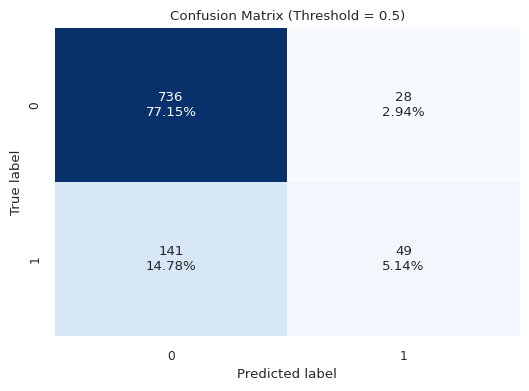

```python
# Initialize Logistic Regression
lr = LogisticRegression()

# Train the model on the training data
lr.fit(X_train_scaled, y_train)

# Evaluate Performance of Logistic Regression Model on Train Data
lr_train_perf = model_performance_classification(lr, X_train_scaled, y_train, 'LR - Original')
display(HTML('<b>Training Performance:</b><br>' + lr_train_perf.to_html()))

# Evaluate Performance of Logistic Regression Model on Test Data
lr_val_perf = model_performance_classification(lr, X_val_scaled, y_val, 'LR - Original')
display(HTML('<br><b>Validation Performance:</b><br>' + lr_val_perf.to_html()))

#Creating confusion matrix on Validation Dataset
display(HTML('<br><b>Confusion Matrix:</b>'))
confusion_matrix_plot(lr,X_val_scaled,y_val)
```

**Observations:**

- **Training Performance:** The model achieved an accuracy of 83%, but with a low recall of 26%, indicating difficulty in identifying defaulters.
- **Validation Performance:** Similar trends are observed in validation, with 82% accuracy and a recall of 26%, suggesting consistency in misclassification.
- **Precision Concerns:** A precision of 67% in training and 64% in validation points to potential false positives, where non-defaulters are incorrectly classified as defaulters.
- **F1 Score Limitation:** The F1 scores (38% training and 37% validation) indicate a balance issue between recall and precision, emphasizing the need for improvement.
- **Confusion Matrix Insights:** The model misclassified 141 actual defaulters as non-defaulters (false negatives), underscoring the importance of enhancing recall for better loan approval predictions.

This analysis suggests the need for further tuning or adjustments, especially considering class imbalance.

### Logistic Regression Model on Oversampled Data using SMOTE

#### Checking the Target Class Imbalance

```python
# Check the distribution of the target variable
print(y_train.value_counts(normalize=True)*100)
```

```
BAD
0.0    80.047195
1.0    19.952805
Name: proportion, dtype: float64
```

**Observations:**

- Target class has imbalance data, we will use data balancing method SMOTE to improve minority class data.

#### Use SMOTE to Balance Target Class

```python
# Apply SMOTE for oversampling
smote = SMOTE()
X_train_resampled, y_train_resampled = smote.fit_resample(X_train_scaled, y_train)
```

#### Build Logistic Regression Model using Balanced Dataset and Evaluate the Performance

**Training Performance:**

|  | Accuracy | Recall | Precision | F1 | ROC_AUC |
| --- | --- | --- | --- | --- | --- |
| LR - Oversampled | 0.725843 | 0.699312 | 0.738499 | 0.718371 | 0.725843 |

**Validation Performance:**

|  | Accuracy | Recall | Precision | F1 | ROC_AUC |
| --- | --- | --- | --- | --- | --- |
| LR - Oversampled | 0.732704 | 0.668421 | 0.398119 | 0.499018 | 0.708556 |

**Confusion Matrix:**

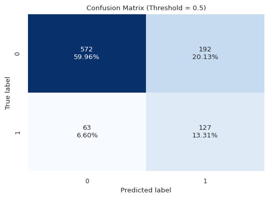

```python
# Fit Logistic Regression model on Balanced Dataset (Resampled)
lr_resampled = LogisticRegression()
lr_resampled.fit(X_train_resampled, y_train_resampled)

# Evaluate Performance of Logistic Regression Model on Train Data
lr_resampled_train_perf = model_performance_classification(lr_resampled, X_train_resampled, y_train_resampled, 'LR - Oversampled')
display(HTML('<b>Training Performance:</b><br>' + lr_resampled_train_perf.to_html()))

# Evaluate Performance of Logistic Regression Model on Validation Data
lr_resampled_val_perf = model_performance_classification(lr_resampled, X_val_scaled, y_val, 'LR - Oversampled')
display(HTML('<br><b>Validation Performance:</b><br>' + lr_resampled_val_perf.to_html()))

#Creating Confusion Matrix on Validation Dataset
display(HTML('<br><b>Confusion Matrix:</b>'))
confusion_matrix_plot(lr_resampled,X_val_scaled,y_val)
```

**Observations:**

**Conclusion:**

While recall improved with oversampling, precision issues necessitate further tuning to achieve better balance, aligning with the project's focus on recall and F1 score.

### Logistic Regression Model on Oversampled Data using Optimal Threshold Value

#### Find the Best Threshold Value with Recall as primary metric

```python
# Find best cut-off threshold
lr_best_threshold = find_optimum_cutoff(lr_resampled, X_train_resampled, y_train_resampled)

# Display the best threshold based on Recall Score
print("Best Threshold:", lr_best_threshold['Threshold'])
print("Performance at Best Threshold:")
display(lr_best_threshold)
```

```
Best Threshold: 0.1
Performance at Best Threshold:
```

|  | 0 |
| --- | --- |
| Threshold | 0.100000 |
| Accuracy | 0.725843 |
| Precision | 0.738499 |
| Recall | 0.699312 |
| F1 Score | 0.718371 |
| ROC-AUC | 0.725843 |

**dtype:** float64

#### Evaluate Performanc on Logistic Regression Model built using Best Threshold on Resampled Data

**Training Performance:**

|  | Accuracy | Recall | Precision | F1 | ROC_AUC |
| --- | --- | --- | --- | --- | --- |
| LR - Optimal Threshold - Oversampled | 0.725843 | 0.699312 | 0.738499 | 0.718371 | 0.725843 |

**Validation Performance:**

|  | Accuracy | Recall | Precision | F1 | ROC_AUC |
| --- | --- | --- | --- | --- | --- |
| LR - Optimal Threshold - Oversampled | 0.732704 | 0.668421 | 0.398119 | 0.499018 | 0.708556 |

**Confusion Matrix:**

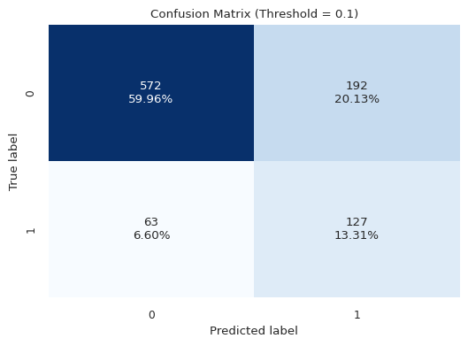

```python
# Evaluate Performance of Logistic Regression Model on Train Data
lr_ot_train_perf = model_performance_classification(lr_resampled, X_train_resampled, y_train_resampled, 'LR - Optimal Threshold - Oversampled',lr_best_threshold['Threshold'])
display(HTML('<b>Training Performance:</b><br>' + lr_ot_train_perf.to_html()))

# Evaluate Performance of Logistic Regression Model on Validation Data
lr_ot_val_perf = model_performance_classification(lr_resampled, X_val_scaled, y_val, 'LR - Optimal Threshold - Oversampled',lr_best_threshold['Threshold'])
display(HTML('<br><b>Validation Performance:</b><br>' + lr_ot_val_perf.to_html()))

#Creating Confusion Matrix on Validation Data
display(HTML('<br><b>Confusion Matrix:</b>'))
confusion_matrix_plot(lr_resampled,X_val_scaled,y_val,lr_best_threshold['Threshold'])
```

**Observations:**

**Conclusion:**

### Logistics Regression Model on Oversampled Data with Hyperparameter Tuning

#### Define Hyper-Paramters, Tune the Model on Resampled Data and Evaluate its Performance

```
Logistic Regression - Oversampled Data:

Best parameters: LogisticRegression(C=0.2),
Best CV Score: 0.6983354350567466
```

**Training Performance:**

|  | Accuracy | Recall | Precision | F1 | ROC_AUC |
| --- | --- | --- | --- | --- | --- |
| LR - Tuned - Oversampled | 0.725843 | 0.699312 | 0.738499 | 0.718371 | 0.725843 |

**Validation Performance:**

|  | Accuracy | Recall | Precision | F1 | ROC_AUC |
| --- | --- | --- | --- | --- | --- |
| LR - Tuned - Oversampled | 0.733753 | 0.668421 | 0.399371 | 0.5 | 0.709211 |

**Confusion Matrix:**

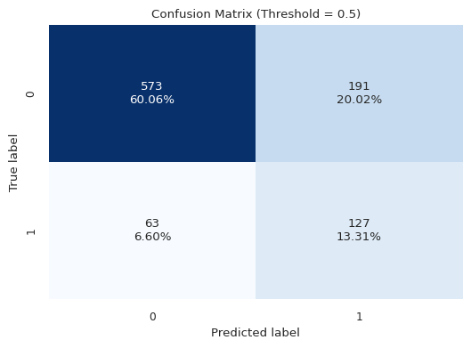

```python
# Define Hyperparameter for Tuning the Model
lr_param_grid = {'C': np.arange(0.1, 1.1,0.1)}

# Get Best Estimator and CV Score on Oversampled Data
best_lr_model_os, best_lr_cv_score_os = tune_model(lr_resampled, X_train_resampled, y_train_resampled, lr_param_grid)

# Display Best Parameters and Score
print('Logistic Regression - Oversampled Data:\n')
print(f'Best parameters: {best_lr_model_os},\nBest CV Score: {best_lr_cv_score_os}\n')

# Evaluate Performance of Logistic Regression Model on Train Data
lr_tuned_train_perf = model_performance_classification(best_lr_model_os, X_train_resampled, y_train_resampled, 'LR - Tuned - Oversampled')
display(HTML('<b>Training Performance:</b><br>' + lr_tuned_train_perf.to_html()))

# Evaluate Performance of Logistic Regression Model on Validation Data
lr_tuned_val_perf = model_performance_classification(best_lr_model_os, X_val_scaled, y_val, 'LR - Tuned - Oversampled')
display(HTML('<br><b>Validation Performance:</b><br>' + lr_tuned_val_perf.to_html()))

#Creating Confusion Matrix for Validation Set
display(HTML('<br><b>Confusion Matrix:</b>'))
confusion_matrix_plot(best_lr_model_os,X_val_scaled,y_val)
```

**Observations:**

**Conclusion:**

Tuned model has not performed any better than previous model, we will now continue to evaluate LDA models.

## Linear Discriminant Analysis (LDA) Models

We will also develop several LDA models to evaluate their performance based on Recall scores and determine how well they generalize to unseen data.

- Model on Original Data
- Model on Oversampled Data (SMOTE)
- Model on Oversampled Data with Optimal Threshold
- Model on Oversampled Data with Hyperparameter Tuning

### LDA Model on Original Data

**Training Performance:**

|  | Accuracy | Recall | Precision | F1 | ROC_AUC |
| --- | --- | --- | --- | --- | --- |
| LDA - Original | 0.824331 | 0.275953 | 0.638298 | 0.385321 | 0.618487 |

**Validation Performance:**

|  | Accuracy | Recall | Precision | F1 | ROC_AUC |
| --- | --- | --- | --- | --- | --- |
| LDA - Original | 0.813417 | 0.273684 | 0.565217 | 0.368794 | 0.610664 |

**Confusion Matrix:**

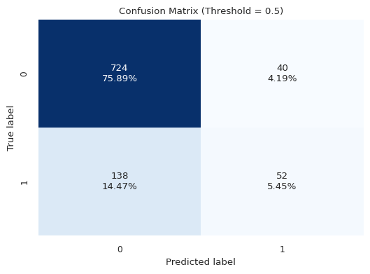

```python
# Initialize LDA
lda = LinearDiscriminantAnalysis()

# Train the LDA model
lda.fit(X_train_scaled, y_train)

# Evaluate Performance of LDA Model on Train Data
lda_train_perf = model_performance_classification(lda, X_train_scaled, y_train, 'LDA - Original')
display(HTML('<b>Training Performance:</b><br>' + lda_train_perf.to_html()))

# Evaluate Performance of LDA Model on Validation Data
lda_val_perf = model_performance_classification(lda, X_val_scaled, y_val, 'LDA - Original')
display(HTML('<br><b>Validation Performance:</b><br>' + lda_val_perf.to_html()))

#Creating Confusion Matrix on Validation Data
display(HTML('<br><b>Confusion Matrix:</b>'))
confusion_matrix_plot(lda,X_val_scaled,y_val)
```

**Observations:**

- **Training Performance:** The LDA model achieved a recall of 27% and an accuracy of 82.43%, indicating challenges in identifying defaulters effectively, particularly with a low F1 score of 38.53%.
- **Validation Performance:** Recall further declined to 27% with an accuracy of 81.34%. Precision also decreased to 56%, highlighting the model's struggle to correctly classify non-defaulters.
- **Confusion Matrix:** The model misclassified 138 actual defaulters (false negatives) and correctly identified 52, indicating significant room for improvement in predicting defaults.

**Conclusion:**

While the LDA model performed reasonably on the training dataset, its low recall and precision suggest a need for further refinement. The model's ability to accurately identify defaulters is insufficient, warranting exploration of alternative approaches or enhancements.

### LDA Model on Oversampled Data

**Training Performance:**

|  | Accuracy | Recall | Precision | F1 | ROC_AUC |
| --- | --- | --- | --- | --- | --- |
| LDA - Oversampled | 0.717655 | 0.694071 | 0.728429 | 0.710835 | 0.717655 |

**Validation Performance:**

|  | Accuracy | Recall | Precision | F1 | ROC_AUC |
| --- | --- | --- | --- | --- | --- |
| LDA - Oversampled | 0.726415 | 0.657895 | 0.389408 | 0.489237 | 0.700675 |

**Confusion Matrix:**

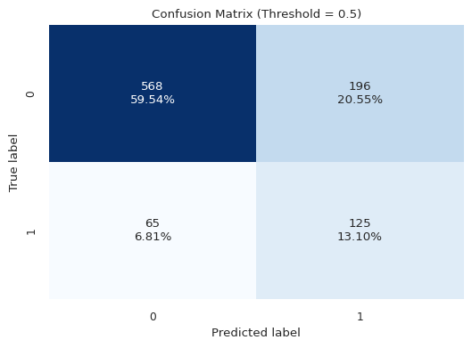

```python
# Initialize LDA on Resampled Data
lda_resampled = LinearDiscriminantAnalysis()

# Train the LDA model
lda_resampled.fit(X_train_resampled, y_train_resampled)

# Evaluate Performance of LDA Model on Train Data
lda_resampled_train_perf = model_performance_classification(lda_resampled, X_train_resampled, y_train_resampled, 'LDA - Oversampled')
display(HTML('<b>Training Performance:</b><br>' + lda_resampled_train_perf.to_html()))

# Evaluate Performance of LDA Model on Validation Data
lda_resampled_val_perf = model_performance_classification(lda_resampled, X_val_scaled, y_val, 'LDA - Oversampled')
display(HTML('<br><b>Validation Performance:</b><br>' + lda_resampled_val_perf.to_html()))

#Creating Confusion Matrix on Validation Set
display(HTML('<br><b>Confusion Matrix:</b>'))
confusion_matrix_plot(lda_resampled,X_val_scaled,y_val)
```

**Observations:**

**Conclusion:**

Although the oversampled LDA model shows improved recall and F1 scores, the precision issues suggest it still struggles with false positives. Further tuning and validation are necessary to enhance its predictive capabilities.